# Jover’s model: description

Mam Malick Sy Ndiaye

25/3/2020

# Model implementation

Here I am going to describe the model of multi-strain multi-phage co-exsistance developed by *Jover et al.* (2013) and my implementation of it in R and Python. Jover’s model describe the population dynamic of a system with multiple hosts (*H<sub>n</sub>*) under predation by multiple phages (*V<sub>n</sub>*) with the following system of differential equations:

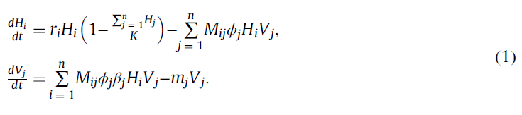

The parameters of this model correspond to life-history-history traits of the hosts and the phages, where:

- *r<sub>i</sub>* [h<sup>-1</sup>]: growth rate of host i
- *K* [cells/ml]: bacterial carrying capacity of the system
- *M<sub>ij</sub>*: infection matrix where the rows correspond to the hosts and the column correspond to the phages. The values in the matrix are either 1 if phage j can infect host i or 0 otherwise.
- *$\phi$<sub>j</sub>* [ml/(virusesxh)]: Absorption rate of virus j. This model assumes no delay between the phage absorption and the cell lysis, which may be problematic.
- *$\beta$<sub>j</sub>* [viruses/cell]: Bust size of virus j (i.e. the number of new virus that get produced following an infection by single phage)
- *m<sub>j</sub>* [h<sup>-1</sup>]: virus decay outside of the host cell.

I implemented this model system in R.

```r
Phage_samples<- paste("P_", 10:1, sep="")
Host_samples<- paste("H_", 10:1, sep="")
rank<- c(1:10)

jover_mod<- function(t, state,parameters){ # function that returns the state of the populations at time t
  with(as.list(c(state,parameters)),{
    H<- state[grepl("H", names(state))]
    V<- state[grepl("V", names(state))]

    dH<- r*H*(1-(sum(H)/k))-colSums(t(red_matrix*H)*V*Ar)
    dV<- rowSums(t(red_matrix*H)*Bs*Ar*V)-(m*V)

    list(c(dH, dV))
  })
}
```

First we will consider cases where the infection matrix is perfectly nested.

```r
# function that takes the number of virus-host pairs and returns a perfectly nested infection matrix
inf_matrix<- function(cpl_size, perfect=T){

  mat<- matrix(rep(0, cpl_size^2),  ncol=cpl_size, nrow = cpl_size)
  for(i in 1:cpl_size){
  mat[i,]<- c(rep(0, cpl_size-i),rep(1, i) )
  }

  colnames(mat)<- paste("P", 1:cpl_size, sep = "")
  rownames(mat)<- paste("H", 1:cpl_size, sep="")

  return(mat)
}

inf_matrix(10) #test the function
```

```
##     P1 P2 P3 P4 P5 P6 P7 P8 P9 P10
## H1   0  0  0  0  0  0  0  0  0   1
## H2   0  0  0  0  0  0  0  0  1   1
## H3   0  0  0  0  0  0  0  1  1   1
## H4   0  0  0  0  0  0  1  1  1   1
## H5   0  0  0  0  0  1  1  1  1   1
## H6   0  0  0  0  1  1  1  1  1   1
## H7   0  0  0  1  1  1  1  1  1   1
## H8   0  0  1  1  1  1  1  1  1   1
## H9   0  1  1  1  1  1  1  1  1   1
## H10  1  1  1  1  1  1  1  1  1   1
```

In these kind of matrixes, the host rank correspond to the number of phages that can infect the host while the virus rank correspond to the number of host that are sensitive to the virus. For instance, H2 can be infected by 2 phages, P9 (can infect 9 hosts) and P10 (can infect 10 hosts).

# Co-exsistance conditions

To find the conditions of co-exsistance of all the strain and phages in the system, we need to find the conditions in which the populations reach steady state. This means finding the solution for $dH~i~/dt=0$ and $dV~i~/dt=0$ for the 2n pairs of equations simultaneously. To solve the ODEs symbolically, I will use a combination of python (sympy package) and sageMath (like MATLAB but worse, it is gratis though):

```r
library(reticulate) # use python on Rmarkdown
```

```python
import sympy as sp
import numpy as np
from IPython.display import display
from sympy.interactive import printing
printing.init_printing(use_latex=True)

# Create the Symbols
n=4 #number of pairs-1 (= 5 pairs phage-bacteria)
i=sp.Idx("i", (0,n)) # Symbolic representation of host i (from 0 to n)
j=sp.Idx("j", (0,n)) # Symbolic representation of virus j (from 0 to n)

H_s= sp.symbols("H:"+str(n+1), integer=True)
V_s=sp.symbols("V:"+str(n+1), integer=True)
Ar_s= sp.symbols("Ar:"+str(n+1), integer=True) #Absorption rate
Bs_s= sp.symbols("Bs:"+str(n+1), integer=True) #Burst Size
r_s= sp.symbols("r:"+str(n+1), integer=True) #growth rate
m_s= sp.symbols("m:"+str(n+1), integer=True) #Virus decay
K= sp.Symbol("K", integer=True) #carrying size
H=sp.Array(H_s) # Array containing n Host symbols
V=sp.Array(V_s) # Array containing n virus symbols
Ar=sp.Array(Ar_s) # Array containing n Absorption rate symbols
Bs=sp.Array(Bs_s) # Array containing n Burst Size symbols
r=sp.Array(r_s) # Array containing n growth rate symbols
m=sp.Array(m_s) # Array containing n virus decay symbols

M= []
for q in range(1,(n+2)):
    tmp=list(np.repeat([0,1], [(n+1)-q,q], axis=0))
    M.append(tmp)
M=sp.Matrix(M) # Infection matrix

# Create a list expressions for the dynamic of each host (exprs1) and phage (exprs2)
exprs1=[]
exprs2=[]
for k in range(n+1):
    exprs1.append(r[k]*H[k]*(1-sp.Sum(H[i], (i, 0,n)).doit()/K)-sp.Sum((M[k,j]*Ar[j]*V[j]*H[k]), (j,0,n)).doit())
    exprs2.append(sp.Sum((M[i,k]*Ar[k]*Bs[k]*V[k]*H[i]), (i,0,n)).doit()- m[k]*V[k])
display(exprs1, exprs2,)

# Put the exprassion in a list of equations (=0) and make a list of variables for wich the equations must be solved (fors; H0, V0, H1...)
```

```
## [-Ar4*H0*V4 + H0*r0*(1 - (H0 + H1 + H2 + H3 + H4)/K), H1*r1*(1 - (H0 + H1 + H2 + H3 + H4)/K) - H1*(Ar3*V3 + Ar4*V4), H2*r2*(1 - (H0 + H1 + H2 + H3 + H4)/K) - H2*(Ar2*V2 + Ar3*V3 + Ar4*V4), H3*r3*(1 - (H0 + H1 + H2 + H3 + H4)/K) - H3*(Ar1*V1 + Ar2*V2 + Ar3*V3 + Ar4*V4), H4*r4*(1 - (H0 + H1 + H2 + …
```

```python
eqs=[]
fors=[]
for i in range(n+1):
    eqs.append(sp.Eq(0, exprs1[i]))
    eqs.append(sp.Eq(0, exprs2[i]))
    fors.append(H[i])
    fors.append(V[i])
```

Python is really slow at solving systems of equations and can manage to generate the results for maximum 2 pairs virus-hosts. Thus, I must employ sageMath (https://www.sagemath.org/) to solve the equations that I have built. Unfortunately, I cannot manage to run sageMath on r, so I will paste the output of the next chuck as an image.

```python
import sage.interfaces.sympy
from sage.interfaces.sympy import sympy_init
sympy_init()

sage_exprs=[]
for i in range(len(exprs1)):
    sage_exprs.append(exprs1[i]._sage_())
    sage_exprs.append(exprs2[i]._sage_()) # Transform the sympy expressions in sageMath expressions

sage_fors=[]
for i in range(len(fors)):
    sage_fors.append(fors[i]._sage_()) # Transform the sympy symbols in sageMath symbols


sage_eqs=[]
for i in range((n+1)*2):
    eq_name=("eq"+str(i))
    globals()[eq_name] = sage_exprs[i]==0
    sage_eqs.append(globals()[eq_name]) #Create Sympy equations

sage_sol=solve(sage_eqs, sage_fors ) # Solve the equations for each bacteria and phage
main_sol=sage_sol[len(sage_sol)-1] # We take only the last solution because is the one that considers coexistance of every member of the community

for i in main_sol:
   show(LatexExpr((i.expand()))) # Display solutions in beautiful LaTex
```

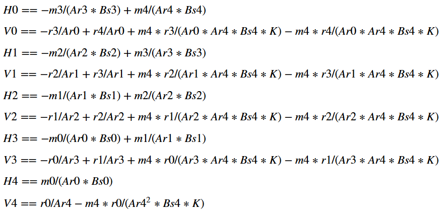

By playng with the number of pairs and studying the solutions, we can conclude that the equilibrum desity of *H<sub>n</sub>* (*Heq<sub>n</sub>*) is determined solely by the life-history traits ($h_j= m_j/(\phi_j \beta_j)$) of V<sub>1</sub> (=*h<sub>1</sub>*), that infects exclusively *H<sub>n</sub>*. *h<sub>j</sub>* is defined as “the host density necessary to support the virus infecting it” and it is a meausure of infectivity: the larger is *h<sub>j</sub>*, the less infective is $V_j$. Therefore, $Heq_{n-1} = h_2 - h_1$ beacuse the density of host *n* is already under control by *V<sub>1</sub>*. Thus, the host density is determined by the differece between the life-history traits of the virus with higher range that infect the host and the virus with the higher range and that do not infect the host.it follows that $Heq_{1} = h_n - h_{n-1}$. finally, we can conclude that the total bacterial biomass at equilibrium is: $\sum_{j=1}^{n}Heq_j= m_n/(\phi_n \beta_n)$. The formula for *Veq* is more complex and is determined by both host and viral life-history traits. However, what is important here is that Veq<sub>1</sub> is dependant on the difference between r<sub>n</sub> and r<sub>n-1</sub>, Veq<sub>2</sub> is dependant on the difference between r<sub>n-1</sub> and r<sub>n-2</sub>, and Veq<sub>n</sub> is dependant on r<sub>1</sub>. We can summarize the densities at equilibrium as:

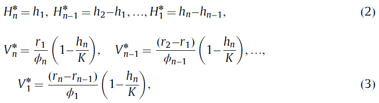

It follow that coexsistance between all member of the community can be acheived only if:

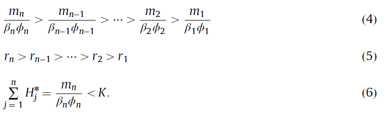

- condition (4) must be respected, otherwise at least one host density will be <0
- condition (5) must be respected, otherwise at least one phage density will be <0
- condition (6) must be respected, otherwise the bacterial biomass will surpass carrying capacitig, driving at least one host extinct

# Simulations of co-exsistance

Now, we can simulate the dynamics of phage-bacteria interactions. First, we will simulate a system in wich condition (4-6) are respected (*Fig. 3 of Jovers et al, 2013*)

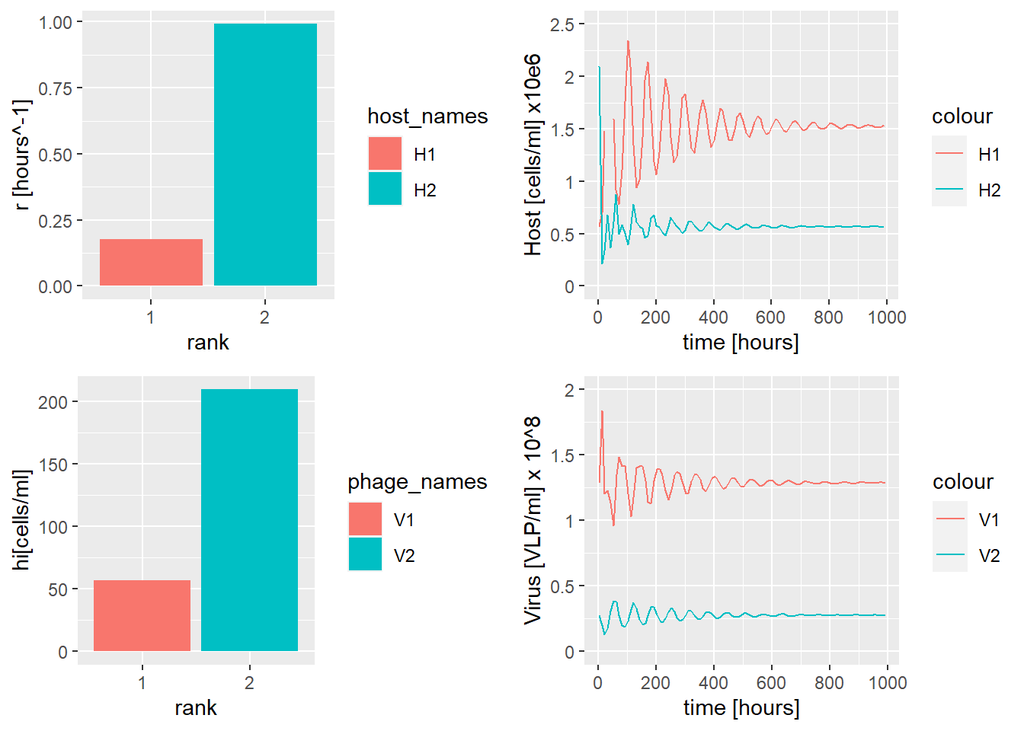

```r
library(deSolve)
library(ggplot2)
library(knitr)
library(reshape2)

couple_size= 2 # 2 host-phage pairs
red_matrix<- inf_matrix(couple_size)

host_names<- paste("H", 1:couple_size, sep="")
phage_names<- paste("V", 1:couple_size, sep="")

#set the parameters and initial conditions
parameters<- list(Ar= c(5e-9, 5e-9), m= c(0.0681, 0.1047), Bs= c(24, 10), r=c(0.1760,0.9914), k=1e7)
times<- seq(1, 1000, by = 10)

# Equilibrium densities
h<- parameters$m/(parameters$Ar*parameters$Bs) # h_i
V_eq<- c(rev(diff(parameters$r)), parameters$r[1])/parameters$Ar*(1-(h[length(h)]/parameters$k)) # Virus density at equilibrium
H_eq<- c(abs(diff(rev(h))),  h[1]) # Host densities at equilibrium
total_biomass<-  sum(parameters$m/(parameters$Ar*parameters$Bs))

rank_info<- data.frame("Eq_host_den"= H_eq, "Eq_virus_den"=V_eq, "growth_rate"=parameters$r, "h[i]"= h) # Table with information on densities in function of rank
rownames(rank_info)<- paste("Rank", 1:length(h))


Fig3_bar_r<-ggplot(data = rank_info, aes(x= as.factor(c(1,2)), y=growth_rate, fill=host_names))+
  geom_bar(stat = "identity")+
  xlab("rank")+
  ylab("r [hours^-1]") # barplot of growth rates
Fig3_bar_hi<-ggplot(data = rank_info, aes(x= as.factor(c(1,2)), y=h.i./1e4, fill=phage_names))+
  geom_bar(stat = "identity")+
  xlab("rank")+
  ylab("hi[cells/ml]") # barplot of h_is

# solve and plot the model
state<-c(h,V_eq) # initial densities at t=0 (I use the equilibrium densities for convenience)
names(state)<- c(host_names, phage_names)
res<- ode(y=state, times = times, func = jover_mod, parms = parameters, method = "ode45") # Solve the system of ODEs thanks to the Jover_mod function

#plot(res) #delete comment to plot singular dynamics
mod_data<- as.data.frame(res)

Fig3_plot_H<- ggplot(data=mod_data)+
  geom_line(aes(time, H1, color="H1"))+
  geom_line(aes(time, H2, color="H2")) +
  scale_y_continuous(name="Host [cells/ml] x10e6", breaks=c(seq(from=0, to=2.5, by=0.5)*1e6), labels=seq(from=0, to=2.5, by=0.5), limits=c(0,2.5)*1e6)+
  scale_x_continuous(name="time [hours]", breaks=seq(0,1000,200), labels=seq(0,1000,200))


Fig3_plot_V<- ggplot(data=mod_data)+
  geom_line(aes(time, V1, color="V1"))+
  geom_line(aes(time, V2, color="V2")) +
  scale_y_continuous(name="Virus [VLP/ml] x 10^8", breaks=c(seq(from=0, to=2, by=0.5)*1e8), labels=seq(from=0, to=2, by=0.5), limits=c(0,2)*1e8) +
  scale_x_continuous(name="time [hours]", breaks=seq(0,1000,200), labels=seq(0,1000,200))

library(cowplot)
plot_grid(Fig3_bar_r, Fig3_plot_H, Fig3_bar_hi, Fig3_plot_V, ncol = 2, nrow = 2)
```

```r
kable(rank_info)
```

|  | Eq_host_den | Eq_virus_den | growth_rate | h.i. |
| --- | --- | --- | --- | --- |
| Rank 1 | 1526500 | 128931048 | 0.1760 | 567500 |
| Rank 2 | 567500 | 27829120 | 0.9914 | 2094000 |

As expected, stable co-exsistance is acheived between the members of the community.

Now we can explore a situtation in wich condition (5) is not respected (Fig. 4 of *Jover et al*., 2013).

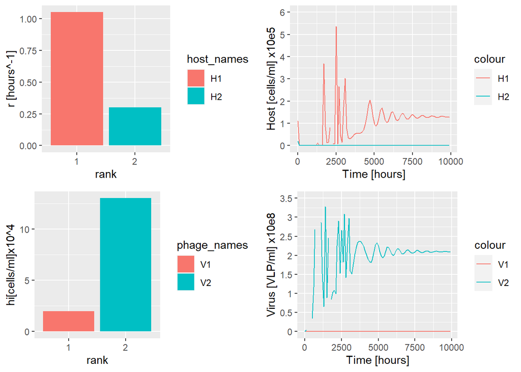

```r
library(deSolve)
library(ggplot2)
library(knitr)

# chose how many couples we want
couple_size= 2
red_matrix<- inf_matrix(couple_size)
host_names<- paste("H", 1:couple_size, sep="")
phage_names<- paste("V", 1:couple_size, sep="")

#set the parameters and initial conditions
parameters<- list(Ar= c(5e-9, 5e-9), m= c(0.0100, 0.0650), Bs= c(100, 100), r=c(1.0500,0.300), k=1e8)
times<- seq(1, 10000, by = 100)

# Equilibrium densities
h<- parameters$m/(parameters$Ar*parameters$Bs)
V_eq<- c(rev(diff(parameters$r)), parameters$r[1])/parameters$Ar*(1-(h[length(h)]/parameters$k))
H_eq<- c(abs(diff(rev(h))),  h[1])
total_biomass<-  sum(parameters$m/(parameters$Ar*parameters$Bs))

rank_info<- data.frame("Eq_host_den"=H_eq, "Eq_virus_den"=V_eq, "growth_rate"=parameters$r, "h[i]"= h)
rownames(rank_info)<- paste("Rank", 1:length(h))

Fig4_bar_r<- ggplot(data = rank_info, aes(x= as.factor(c(1,2)), y=growth_rate, fill=host_names))+
  geom_bar(stat = "identity")+
  xlab("rank")+
  ylab("r [hours^-1]")
Fig4_bar_hi<- ggplot(data = rank_info, aes(x= as.factor(c(1,2)), y=h.i./1e4, fill=phage_names))+
  geom_bar(stat = "identity")+
  xlab("rank")+
  ylab("hi[cells/ml]x10^4")


#solve and plot the model
state<-c(H_eq,H_eq)
names(state)<- c(host_names, phage_names)
res<- ode(y=state, times = times, func = jover_mod, parms = parameters, method = "ode45")
#plot(res)

mod_data<- as.data.frame(res)

Fig4_plot_H<- ggplot(data=mod_data)+
  geom_line(aes(time, H1, color="H1"))+
  geom_line(aes(time, H2, color="H2")) +
  scale_y_continuous(name="Host [cells/ml] x10e5", breaks=c(seq(from=0, to=6, by=1)*1e5), labels=seq(from=0, to=6, by=1), limits=c(0,6)*1e5)+
  xlab("Time [hours]")

Fig4_plot_V<- ggplot(data=mod_data)+
  geom_line(aes(time, V1, color="V1"))+
  geom_line(aes(time, V2, color="V2")) +
  scale_y_continuous(name="Virus [VLP/ml] x10e8", breaks=c(seq(from=0, to=3.5, by=0.5)*1e8), labels=seq(from=0, to=3.5, by=0.5), limits=c(0,3.5)*1e8)+
  xlab("Time [hours]")

library(cowplot)
plot_grid(Fig4_bar_r, Fig4_plot_H, Fig4_bar_hi, Fig4_plot_V, ncol = 2, nrow = 2)
```

```r
kable(rank_info)
```

|  | Eq_host_den | Eq_virus_den | growth_rate | h.i. |
| --- | --- | --- | --- | --- |
| Rank 1 | 110000 | -149805000 | 1.05 | 20000 |
| Rank 2 | 20000 | 209727000 | 0.30 | 130000 |

Until conditions (4-6) are satisfied, with a perfect infection network we can observe coexistance between an infinite number of host-phage pairs. We will simulate co-exsistance between 5 host-bacteria pairs (Fig. 6 of *jover et al.*, 2013).

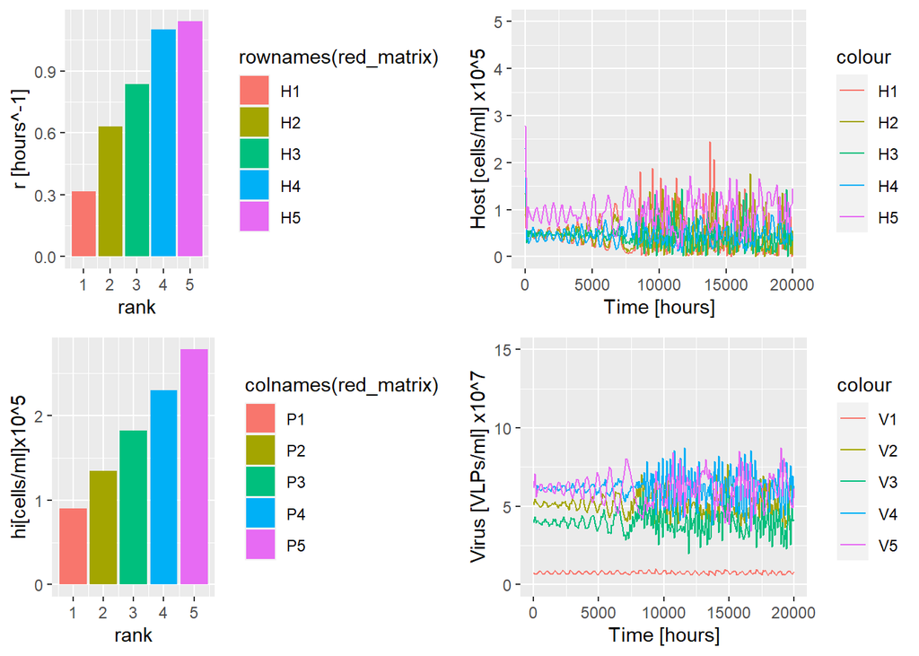

```r
library(deSolve)
library(ggplot2)
library(knitr)

# chose how many couples we want and create an infection matrix
couple_size= 5
host_names<- paste("H", 1:couple_size, sep="")
phage_names<- paste("V", 1:couple_size, sep="")

red_matrix<- inf_matrix(couple_size)

#set the parameters and initial conditions
parameters<- list(Ar= rep(5e-9, couple_size), m= c(0.0090, 0.0270,0.0548,0.0922,0.1392), Bs= c(20, 40,60,80,100), r=c(0.3162,0.6325, 0.8367, 1.1000, 1.1400), k=1e7)
times<- seq(0, 20000, by = 100)

#Equilibrium densities
h<- parameters$m/(parameters$Ar*parameters$Bs)
V_eq<- c(rev(diff(parameters$r)), parameters$r[1])/parameters$Ar*(1-(h[length(h)]/parameters$k))
H_eq<- c(abs(diff(rev(h))),  h[1])
total_biomass<-  sum(parameters$m/(parameters$Ar*parameters$Bs))

rank_info<- data.frame("Eq_host_den"=H_eq, "Eq_virus_den"=V_eq, "growth_rate"=parameters$r, "h[i]"= h)
rownames(rank_info)<- paste("Rank", 1:length(h))

Fig6_bar_r<-ggplot(data = rank_info, aes(x= c(1:5), y=growth_rate, fill=rownames(red_matrix)))+
  geom_bar(stat = "identity")+
  xlab("rank")+
  ylab("r [hours^-1]")
Fig6_bar_hi<-ggplot(data = rank_info, aes(x= c(1:5), y=h.i./1e5, fill= colnames(red_matrix)))+
  geom_bar(stat = "identity")+
  xlab("rank")+
  ylab("hi[cells/ml]x10^5")

#solve and plot the model
state<-c(h,V_eq)
names(state)<- c(host_names, phage_names)

res<- ode(y=state, times = times, func = jover_mod, parms = parameters, method = "ode45")
#plot(res)

mod_data<- as.data.frame(res)

Fig6_plot_H<-ggplot(data=mod_data)+
  geom_line(aes(time, H1, color="H1"))+
  geom_line(aes(time, H2, color="H2")) +
  geom_line(aes(time, H3, color="H3")) +
  geom_line(aes(time, H4, color="H4")) +
  geom_line(aes(time, H5, color="H5")) +
  scale_y_continuous(name="Host [cells/ml] x10^5", breaks=c(seq(from=0, to=5, by=1)*1e5), labels=seq(from=0, to=5, by=1), limits=c(0,5)*1e5)+
  xlab("Time [hours]")


Fig6_plot_V<- ggplot(data=mod_data)+
  geom_line(aes(time, V1, color="V1"))+
  geom_line(aes(time, V2, color="V2")) +
  geom_line(aes(time, V3, color="V3")) +
  geom_line(aes(time, V4, color="V4")) +
  geom_line(aes(time, V5, color="V5")) +
    scale_y_continuous(name="Virus [VLPs/ml] x10^7", breaks=c(seq(from=0, to=15, by=5)*1e7), labels=seq(from=0, to=15, by=5), limits=c(0,15)*1e7)+
  xlab("Time [hours]")

library(cowplot)
plot_grid(Fig6_bar_r, Fig6_plot_H, Fig6_bar_hi, Fig6_plot_V, ncol = 2, nrow = 2)
```

```r
kable(rank_info)
```

|  | Eq_host_den | Eq_virus_den | growth_rate | h.i. |
| --- | --- | --- | --- | --- |
| Rank 1 | 47900.00 | 7777280 | 0.3162 | 90000.0 |
| Rank 2 | 47833.33 | 51193946 | 0.6325 | 135000.0 |
| Rank 3 | 47666.67 | 39703014 | 0.8367 | 182666.7 |
| Rank 4 | 45000.00 | 61498842 | 1.1000 | 230500.0 |
| Rank 5 | 90000.00 | 61479398 | 1.1400 | 278400.0 |

As expected, co-existence is attained.

# Imperfectly nested Infection Matrix

All the above-mentioned results are obtained in the case of a perfectly nested infection matrix. If the matrix is imperfectly nested, we can consider in two types of situations: The matrix is invertible or the matrix is singular.

## Example of invertible matrix

```r
inv_matrix<- inf_matrix(4)
inv_matrix[3,2]<-0
inv_matrix[2,2]<-1
inv_matrix[3,1]<-1

inv_matrix
```

```
##    P1 P2 P3 P4
## H1  0  0  0  1
## H2  0  1  1  1
## H3  1  0  1  1
## H4  1  1  1  1
```

```r
paste("determinant:", det(inv_matrix)) # if the determinant is !=0, the matrix is invertible, otherwise is singular
```

```
## [1] "determinant: -1"
```

An imperfectly nested invertible matrix corresponds to an infection network where there is no overlap between the host ranges of the phages

## Example of singular matrix

```r
sing_matrix<- inf_matrix(4)
sing_matrix[3,1]<-1

sing_matrix
```

```
##    P1 P2 P3 P4
## H1  0  0  0  1
## H2  0  0  1  1
## H3  1  1  1  1
## H4  1  1  1  1
```

```r
paste("determinant:", det(sing_matrix)) # if the determinant is !=0, the matrix is invertible, otherwise is singular
```

```
## [1] "determinant: 0"
```

To determinate wether a co-exsistence is possible in these two cases, jover and collegues express the equilibrium densities of viruses and hosts in the following terms:

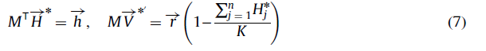

An equation of type $AX=B$, where *A* is a matrix while *X* and *B* are vectors, has a single solution: $X=BA^{-1}$. Therefore, to solve the system A needs to be invertible and system (7) has a solution only if M is invertible. Thus, if there is *no* host range overlap between phages, co-exsistance is possible in an imperfectly nested infection matrix. For every inverible infection network will exsist a combination of bacterial and viral life-history trais that will allow positive equilibrum densities for all members of the communities (similar to condition 4-6). We will simulate co-exsistance between 4 host-bacteria pairs in an imperfectly nested and inversible infection network (Fig. 8 of *jover et al.*, 2013).

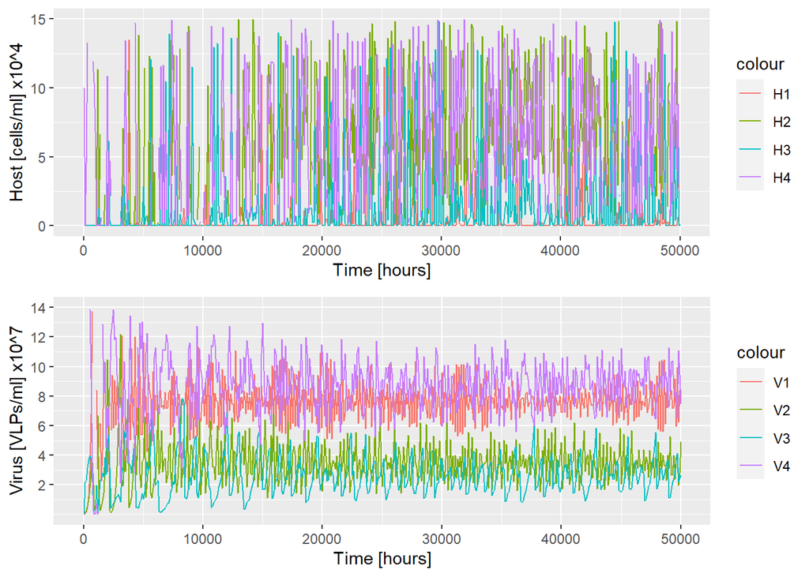

```r
library(deSolve)
library(ggplot2)

# chose how many couples we want and create an infection matrix
couple_size= 4
red_matrix<- inv_matrix
host_names<- paste("H", 1:couple_size, sep="")
phage_names<- paste("V", 1:couple_size, sep="")

#set the parameters and initial conditions
parameters<- list(Ar= rep(5e-9, couple_size), m= c(0.0100, 0.0375,0.0650,0.0925), Bs= c(20, 46,70,96), r=c(0.4472,0.7583, 0.9747, 1.1511), k=1e7)
times<- seq(0, 50000, by = 100)

#solve and plot the model
state<-rep(10e4, couple_size*2)
names(state)<- c(host_names, phage_names)

res<- ode(y=state, times = times, func = jover_mod, parms = parameters, method = "ode45")
#plot(res)

mod_data<- as.data.frame(res)

Fig8_plot_H<-ggplot(data=mod_data)+
  geom_line(aes(time, H1, color="H1"))+
  geom_line(aes(time, H2, color="H2")) +
  geom_line(aes(time, H3, color="H3")) +
  geom_line(aes(time, H4, color="H4")) +
  scale_y_continuous(name="Host [cells/ml] x10^4", breaks=c(seq(from=0, to=15, by=5)*1e4), labels=seq(from=0, to=15, by=5), limits=c(0,15)*1e4)+
  xlab("Time [hours]")


Fig8_plot_V<- ggplot(data=mod_data)+
  geom_line(aes(time, V1, color="V1"))+
  geom_line(aes(time, V2, color="V2")) +
  geom_line(aes(time, V3, color="V3")) +
  geom_line(aes(time, V4, color="V4")) +
    scale_y_continuous(name="Virus [VLPs/ml] x10^7", breaks=c(seq(from=2, to=14, by=2)*1e7), labels=seq(from=2, to=14, by=2), limits=c(0,14)*1e7)+
  xlab("Time [hours]")

library(cowplot)
plot_grid(Fig8_plot_H, Fig8_plot_V, ncol = 1, nrow = 2)
```

As expected, co-existance is attained.

If the matrix is singular, the system $AX=B$ has either no or infinite solutions. Thus, for all intents and porpuses co-exsistance is not possible when overlap occours between the host ranges of two or more phages. However, the authors point out that a solution can be found if we assume that the absorption rate and burst size of phages change from host to host. This assumption is likely more biologically correct and would trasorm the matrix M in a weighted matrix, insed of a binary matrix. Thus, each element of M would correspond to the weight of the virus life-history traits on each host. In this case, the matrix can be invertible also with host ranges overlap and a solution to system (7) can be found. (maybe we should include it in the model)

*p.s.: I’m not super good in math, so this whole section on inversible/singular matrixes may be wrong.*